# Guia 1: Machine Learning 1

## Relación entre minutos e ingresos de los clientes

### Carlos Gabriel Contreras

```python
import pandas as pd
import numpy as np
from scipy import stats
import scipy.stats as stats
import math
import matplotlib.pyplot as plt
from statsmodels.stats.multitest import multipletests
import seaborn as sns
from sklearn.decomposition import PCA
from sklearn.preprocessing import StandardScaler
from scipy.stats import chi2
import statsmodels.api as sm
import statsmodels.formula.api as smf
```

```python
ABT_1 = pd.read_csv('/Users/ccs/Documents/UNIVERSIDAD/Especialización en Machine Learning/Machine Learning 1/Guía 1/Machine-Learning/Credito_dias.csv')
print(ABT_1.head())

import pandas as pd
import numpy as np

nan_table = ABT_1.isna().sum().to_frame(name='Cantidad de NaN')
nan_table['Porcentaje (%)'] = (ABT_1.isna().mean() * 100).round(2)

nan_table

ABT_1['creditcd'] = ABT_1['creditcd'].replace("nan", np.nan)
ABT_1['creditcd'] = ABT_1['creditcd'].fillna("NR")

ABT_1['creditcd'].value_counts(dropna=False)
```

```
    totmou   totrev creditcd  eqpdays  Customer_ID
0   7269.0   906.58        Y      371      1082423
1  13552.0  1172.25        N       83      1069232
2   4152.0   577.39        Y      675      1031705
3   1863.0   294.26        Y      218      1089806
4   4155.0   433.16        N      222      1076695
```

```
creditcd
Y     6796
N     3052
NR     152
Name: count, dtype: int64
```

### Análisis expoloratorio univariado

#### Ingresos del cliente

##### Procedimiento.

Mediante la regla de Sturges se crean rangos de la variable "ingesos del cliente", lo que facilita la creación de tablas de frecuencia y visualizar la distribución de la variable.

Aunque se puede optar por analizar univariadamente los atipicos, se prefiere hacer análisis de atípicos multivariados, esto dada la pregunta general sobre encontrar la relación entre ambas variables: Ingresos de cliente vs minutos

```python
n = len(ABT_1['totrev'].dropna())
k = math.ceil(1 + 3.322 * math.log10(n))

ABT_1['totrev_R'] = pd.cut(ABT_1['totrev'], bins=k)
ABT_1['totrev_R'] = ABT_1['totrev_R'].cat.add_categories('vacíos').fillna('vacíos')

frequency_table_1 = ABT_1['totrev_R'].value_counts(sort=False).to_frame(name='Frecuencia Absoluta')
frequency_table_1['Frecuencia Relativa'] = (frequency_table_1['Frecuencia Absoluta'] / len(ABT_1)).round(4)

frequency_table_1.index.name = 'Categoría de totrev_R'
frequency_table_1.reset_index(inplace=True)

print(frequency_table_1)
```

```
     Categoría de totrev_R  Frecuencia Absoluta  Frecuencia Relativa
0        (-2.316, 905.467]                 5557               0.5557
1      (905.467, 1799.833]                 3278               0.3278
2       (1799.833, 2694.2]                  769               0.0769
3       (2694.2, 3588.567]                  200               0.0200
4     (3588.567, 4482.933]                   93               0.0093
5       (4482.933, 5377.3]                   49               0.0049
6       (5377.3, 6271.667]                   27               0.0027
7     (6271.667, 7166.033]                   10               0.0010
8       (7166.033, 8060.4]                    5               0.0005
9       (8060.4, 8954.767]                    7               0.0007
10    (8954.767, 9849.133]                    1               0.0001
11     (9849.133, 10743.5]                    1               0.0001
12    (10743.5, 11637.867]                    0               0.0000
13  (11637.867, 12532.233]                    0               0.0000
14    (12532.233, 13426.6]                    3               0.0003
15                  vacíos                    0               0.0000
```

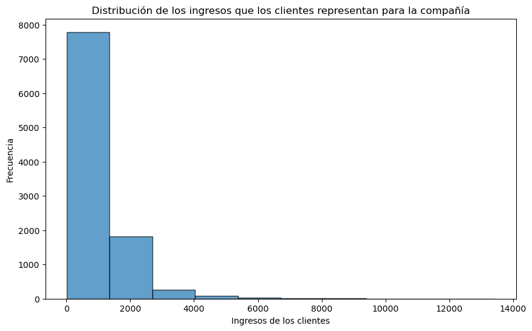

```
                               Estadístico          Valor
0                                    Media    1042.133807
1                                  Mediana     820.235000
2                                     Moda     552.600000
3                      Desviación Estándar     857.144895
4                                 Varianza  734697.371400
5   Coeficiente de Apuntamiento (Kurtosis)      25.629132
6                           Cuartil 1 (Q1)     526.787500
7                   Cuartil 2 (Mediana/Q2)     820.235000
8                           Cuartil 3 (Q3)    1272.975000
9                                   Mínimo      11.100000
10                                  Máximo   13426.600000
```

```python
plt.figure(figsize=(10, 6))
plt.hist(ABT_1['totrev'].dropna(), bins=10, edgecolor='black', alpha=0.7)
plt.title('Distribución de los ingresos que los clientes representan para la compañía')
plt.xlabel('Ingresos de los clientes')
plt.ylabel('Frecuencia')
plt.show()

statistics = {
    'Media': ABT_1['totrev'].mean(),
    'Mediana': ABT_1['totrev'].median(),
    'Moda': ABT_1['totrev'].mode()[0] if not ABT_1['totrev'].mode().empty else None,
    'Desviación Estándar': ABT_1['totrev'].std(),
    'Varianza': ABT_1['totrev'].var(),
    'Coeficiente de Apuntamiento (Kurtosis)': ABT_1['totrev'].kurt(),
    'Cuartil 1 (Q1)': ABT_1['totrev'].quantile(0.25),
    'Cuartil 2 (Mediana/Q2)': ABT_1['totrev'].quantile(0.5),
    'Cuartil 3 (Q3)': ABT_1['totrev'].quantile(0.75),
    'Mínimo': ABT_1['totrev'].min(),
    'Máximo': ABT_1['totrev'].max()
}

statistics_df = pd.DataFrame(list(statistics.items()), columns=['Estadístico', 'Valor'])
print(statistics_df)
```

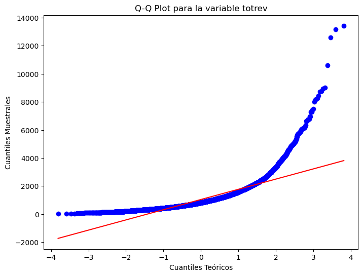

```
(0.7202707690753343, 5.755235033783246e-84)
```

```python
plt.figure(figsize=(8, 6))
stats.probplot(ABT_1['totrev'].dropna(), dist="norm", plot=plt)
plt.title('Q-Q Plot para la variable totrev')
plt.xlabel('Cuantiles Teóricos')
plt.ylabel('Cuantiles Muestrales')
plt.show()

# Realizar la prueba de normalidad Shapiro-Wilk
normality_test = stats.shapiro(ABT_1['totrev'].dropna())
normality_statistic = normality_test.statistic
p_value = normality_test.pvalue

normality_statistic, p_value
```

```python
mean = ABT_1.groupby('creditcd')['totrev'].mean()
median = ABT_1.groupby('creditcd')['totrev'].median()
se_mean = ABT_1.groupby('creditcd')['totrev'].apply(lambda x: np.std(x, ddof=1) / np.sqrt(len(x)))

results = pd.DataFrame({
    'Mean': mean,
    'SEMean': se_mean,
    'Median': median
}).reset_index()

confidence_level = 0.95
z_score = stats.norm.ppf(1 - (1 - confidence_level) / 2)

results['Mean.LCL'] = results['Mean'] - z_score * results['SEMean']
results['Mean.UCL'] = results['Mean'] + z_score * results['SEMean']
results['Median.LCL'] = results['Median'] - 1.57 * results['SEMean']
results['Median.UCL'] = results['Median'] + 1.57 * results['SEMean']

print(results[['creditcd', 'Mean.LCL', 'Mean', 'Mean.UCL', 'SEMean', 'Median.LCL', 'Median', 'Median.UCL']])

categories = ABT_1['creditcd'].dropna().unique()

pairs = []
p_values = []

for i in range(len(categories)):
    for j in range(i + 1, len(categories)):
        group1 = ABT_1[ABT_1['creditcd'] == categories[i]]['totrev'].dropna()
        group2 = ABT_1[ABT_1['creditcd'] == categories[j]]['totrev'].dropna()

        t_stat, p_val = stats.ttest_ind(group1, group2, equal_var=False)  # Welch's t-test
        pairs.append(f"{categories[i]} vs {categories[j]}")
        p_values.append(p_val)


_, p_adjusted, _, _ = multipletests(p_values, alpha=0.05, method='fdr_bh')


results_df = pd.DataFrame({
    'Comparación': pairs,
    'Valor p sin ajustar': p_values,
    'Valor p ajustado (BH)': p_adjusted
})

print(results_df)
```

```
  creditcd     Mean.LCL         Mean     Mean.UCL     SEMean  Median.LCL  \
0        N  1004.843428  1035.948303  1067.053178  15.870126  781.803903
1       NR   903.075445  1031.229211  1159.382976  65.385776  710.299332
2        Y  1024.960565  1045.155534  1065.350504  10.303745  811.323120

    Median  Median.UCL
0  806.720  831.636097
1  812.955  915.610668
2  827.500  843.676880
  Comparación  Valor p sin ajustar  Valor p ajustado (BH)
0      Y vs N             0.626562               0.944168
1     Y vs NR             0.833633               0.944168
2     N vs NR             0.944168               0.944168
```

En ausencia de valores perdidos en la variable para intervenir, a continuación algunos comentarios parciales:

1. La media es de 1042.13, mientras que la mediana es más baja, en 820.24. Esta diferencia sugiere que los ingresos están sesgados hacia la derecha (positivamente), probablemente debido a algunos ingresos muy altos que elevan el promedio.
2. La moda está en 552.6, lo que indica que la mayoría de los clientes tienen ingresos alrededor de esta cifra, considerablemente por debajo de la media. Esto refuerza la idea de una distribución sesgada.
3. La desviación estándar es alta (857.14), lo que implica que los ingresos son muy variables entre los clientes. La varianza (734697.37) también es considerablemente alta, confirmando que los ingresos tienen una gran dispersión alrededor de la media.
4. El coeficiente de apuntamiento es alto (25.63), lo que sugiere que la distribución es leptocúrtica, con una alta concentración de valores cerca de la media y colas más pesadas. Esto significa que algunos clientes tienen ingresos extremadamente altos, lo que genera valores atípicos (outliers) en los datos.
5. Cuartiles:
   - Q1 (526.79) y Mediana (820.24) indican que el 50% de los clientes tienen ingresos por debajo de 820.24.
   - Q3 (1272.98) muestra que el 75% de los clientes ganan menos de esta cifra.
   - El mínimo y el máximo (11.1 y 13426.6, respectivamente) indican un rango extremadamente amplio de ingresos.

Estos estadísticos sugieren una distribución de ingresos asimétrica, con la mayoría de los clientes en niveles de ingreso bajos o medios, pero con una pequeña proporción de clientes con ingresos muy altos que elevan la media. La alta dispersión y apuntamiento indican que estos valores extremos están significativamente alejados del resto de la distribución.

### Análisis expoloratorio univariado

#### Total de minutos usados por el cliente.

```python
nan_count = ABT_1['totmou'].isna().sum()
print(f"Número de valores NaN en 'totmou': {nan_count}")

# Eliminar filas con valores NaN en `totmou`
ABT_1 = ABT_1.dropna(subset=['totmou']).reset_index(drop=True)

# Verificar que se eliminaron
print(f"Número de valores NaN en 'totmou' después de la eliminación: {ABT_1['totmou'].isna().sum()}")
```

```
Número de valores NaN en 'totmou': 0
Número de valores NaN en 'totmou' después de la eliminación: 0
```

```
       Categoría de totrev_R  Frecuencia Absoluta  Frecuencia Relativa
0      (-163.264, 10884.278]                 7888               0.7888
1     (10884.278, 21768.557]                 1596               0.1596
2     (21768.557, 32652.835]                  340               0.0340
3     (32652.835, 43537.114]                   89               0.0089
4     (43537.114, 54421.392]                   43               0.0043
5     (54421.392, 65305.671]                   17               0.0017
6     (65305.671, 76189.949]                   10               0.0010
7     (76189.949, 87074.228]                    7               0.0007
8     (87074.228, 97958.506]                    3               0.0003
9    (97958.506, 108842.784]                    2               0.0002
10  (108842.784, 119727.063]                    3               0.0003
11  (119727.063, 130611.341]                    0               0.0000
12   (130611.341, 141495.62]                    1               0.0001
13   (141495.62, 152379.898]                    0               0.0000
14  (152379.898, 163264.177]                    1               0.0001
15                    varios                    0               0.0000
```

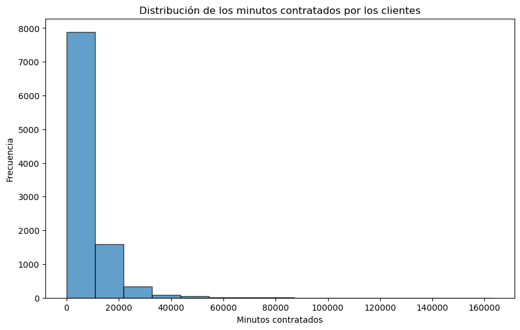

```
                Estadístico         Valor
0                     Media  7.692805e+03
1                   Mediana  5.262000e+03
2                      Moda  1.581000e+03
3       Desviación Estándar  8.657918e+03
4                  Varianza  7.495954e+07
5          Sesgo (Skewness)  4.326137e+00
6   Apuntamiento (Kurtosis)  3.727990e+01
7            Cuartil 1 (Q1)  2.576000e+03
8    Cuartil 2 (Mediana/Q2)  5.262000e+03
9            Cuartil 3 (Q3)  9.823250e+03
10                   Mínimo  0.000000e+00
11                   Máximo  1.632642e+05
```

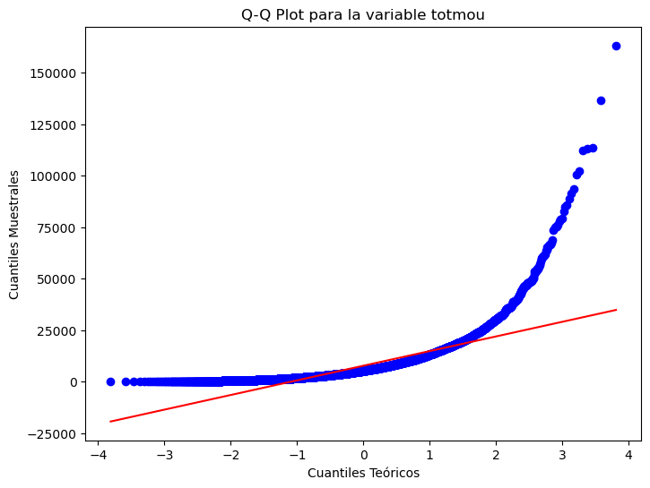

```
(0.6744305169919635, 1.9772665350547702e-87)
```

```python
n = len(ABT_1['totmou'].dropna())
k = math.ceil(1 + 3.322 * math.log10(n))

ABT_1['totmou_2'] = pd.cut(ABT_1['totmou'], bins=k)
ABT_1['totmou_2'] = ABT_1['totmou_2'].cat.add_categories('varios').fillna('varios')

frequency_table_2 = ABT_1['totmou_2'].value_counts(sort=False).to_frame(name='Frecuencia Absoluta')
frequency_table_2['Frecuencia Relativa'] = (frequency_table_2['Frecuencia Absoluta'] / len(ABT_1)).round(4)

frequency_table_2.index.name = 'Categoría de totrev_R'
frequency_table_2.reset_index(inplace=True)

print(frequency_table_2)

plt.figure(figsize=(10, 6))
plt.hist(ABT_1['totmou'].dropna(), bins=k, edgecolor='black', alpha=0.7)
plt.title('Distribución de los minutos contratados por los clientes')
plt.xlabel('Minutos contratados')
plt.ylabel('Frecuencia')
plt.show()

statistics = {
    'Media': ABT_1['totmou'].mean(),
    'Mediana': ABT_1['totmou'].median(),
    'Moda': ABT_1['totmou'].mode()[0] if not ABT_1['totmou'].mode().empty else None,
    'Desviación Estándar': ABT_1['totmou'].std(),
    'Varianza': ABT_1['totmou'].var(),
    'Sesgo (Skewness)': ABT_1['totmou'].skew(),
    'Apuntamiento (Kurtosis)': ABT_1['totmou'].kurt(),
    'Cuartil 1 (Q1)': ABT_1['totmou'].quantile(0.25),
    'Cuartil 2 (Mediana/Q2)': ABT_1['totmou'].quantile(0.5),
    'Cuartil 3 (Q3)': ABT_1['totmou'].quantile(0.75),
    'Mínimo': ABT_1['totmou'].min(),
    'Máximo': ABT_1['totmou'].max()
}

statistics_df = pd.DataFrame(list(statistics.items()), columns=['Estadístico', 'Valor'])
print(statistics_df)


plt.figure(figsize=(8, 6))
stats.probplot(ABT_1['totmou'].dropna(), dist="norm", plot=plt)
plt.title('Q-Q Plot para la variable totmou')
plt.xlabel('Cuantiles Teóricos')
plt.ylabel('Cuantiles Muestrales')
plt.show()

normality_test_totmou = stats.shapiro(ABT_1['totmou'].dropna())
normality_statistic_totmou = normality_test_totmou.statistic
p_value_totmou = normality_test_totmou.pvalue

normality_statistic_totmou, p_value_totmou
```

La mayoría de los clientes contratan menos minutos, con una mediana de 5262 y una moda de 1581 minutos, lo que indica que los valores más comunes están por debajo del promedio. Sin embargo, algunos clientes contratan una cantidad mucho mayor de minutos, lo que eleva la media a 7692 y aumenta la variabilidad en los datos. Estos contratos extremos hacen que la distribución esté sesgada hacia la derecha y tenga una alta dispersión y concentración en valores atípicos.

Los datos no parecen provenir de una distribución normal de acuerdo al test de Shapiro Wilks.

```python
grouped = ABT_1.groupby('creditcd')['totmou']
mean = grouped.mean()
se_mean = grouped.apply(lambda x: np.std(x, ddof=1) / np.sqrt(len(x)))
median = grouped.median()


confidence_level = 0.95
z_score = stats.norm.ppf(1 - (1 - confidence_level) / 2)
results = pd.DataFrame({
    'Mean': mean,
    'SEMean': se_mean,
    'Mean.LCL': mean - z_score * se_mean,
    'Mean.UCL': mean + z_score * se_mean,
    'Median': median,
    'Median.LCL': median - 1.57 * se_mean,  # Aproximación de IC para la mediana
    'Median.UCL': median + 1.57 * se_mean
}).reset_index()


categories = ABT_1['creditcd'].unique()
pairs = []
p_values = []

for i in range(len(categories)):
    for j in range(i + 1, len(categories)):
        group1 = ABT_1[ABT_1['creditcd'] == categories[i]]['totmou'].dropna()
        group2 = ABT_1[ABT_1['creditcd'] == categories[j]]['totmou'].dropna()

        # Prueba t para muestras independientes (Welch's t-test)
        t_stat, p_val = stats.ttest_ind(group1, group2, equal_var=False)
        pairs.append(f"{categories[i]} vs {categories[j]}")
        p_values.append(p_val)

# 4. Ajuste de Benjamini-Hochberg (BH) para el control de errores
_, p_adjusted, _, _ = multipletests(p_values, alpha=0.05, method='fdr_bh')

# Resultados en un DataFrame
comparison_results = pd.DataFrame({
    'Comparación': pairs,
    'Valor p sin ajustar': p_values,
    'Valor p ajustado (BH)': p_adjusted
})

# Mostrar resultados
print("Estadísticos por categoría de `creditcd`:\n", results)
print("\nResultados de comparación de medias con ajuste BH:\n", comparison_results)
```

```
Estadísticos por categoría de `creditcd`:
   creditcd         Mean      SEMean     Mean.LCL     Mean.UCL  Median  \
0        N  8288.588805  156.035278  7982.765280  8594.412330  6021.5
1       NR  7362.664101  682.098804  6025.775012  8699.553190  5394.5
2        Y  7432.629588  105.149370  7226.540609  7638.718567  4964.5

    Median.LCL   Median.UCL
0  5776.524614  6266.475386
1  4323.604878  6465.395122
2  4799.415489  5129.584511

Resultados de comparación de medias con ajuste BH:
   Comparación  Valor p sin ajustar  Valor p ajustado (BH)
0      Y vs N             0.000005               0.000016
1     Y vs NR             0.919380               0.919380
2     N vs NR             0.187548               0.281323
```

Los clientes que no tienen tarjeta de credito suelen acumular mas minutos en ptomedio oscilando entre 7982.76 y 8594.41 en comparación a los usuarios que tienen tarjeta en quienes el promedio de minutos acumula entre 7226.54 y 7638.71. Al comparar el promedio de minutos en los dos grupos, se observa que la diferencia es estadísticamente significativa al 95% de confianza.

### Análisis expoloratorio univariado

#### Indicador de tarjeta de crédito.

```
Tabla de Frecuencias para `creditcd`:
           Frecuencia  Frecuencia Relativa (%)
creditcd
Y               6796                    67.96
N               3052                    30.52
NR               152                     1.52
```

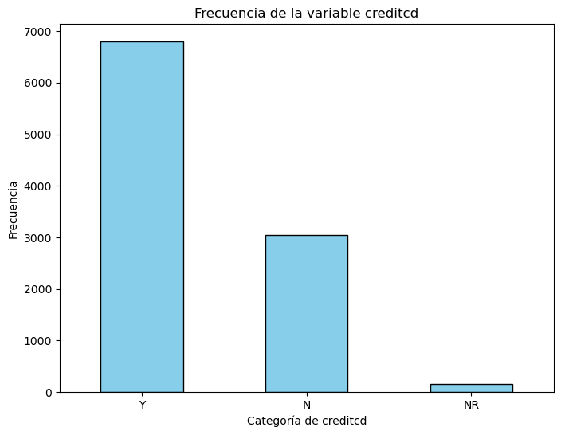

```python
frequency_table = ABT_1['creditcd'].value_counts().to_frame(name='Frecuencia')
frequency_table['Frecuencia Relativa (%)'] = (frequency_table['Frecuencia'] / frequency_table['Frecuencia'].sum() * 100).round(2)

print("Tabla de Frecuencias para `creditcd`:\n", frequency_table)

plt.figure(figsize=(8, 6))
frequency_table['Frecuencia'].plot(kind='bar', color='skyblue', edgecolor='black')
plt.title('Frecuencia de la variable creditcd')
plt.xlabel('Categoría de creditcd')
plt.ylabel('Frecuencia')
plt.xticks(rotation=0)
plt.show()
```

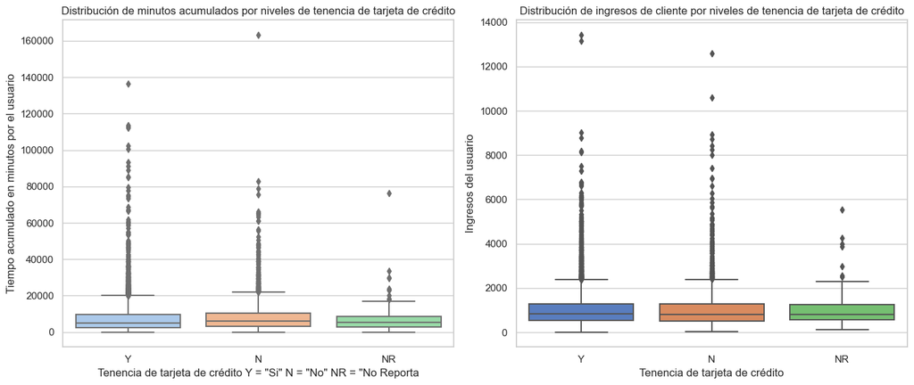

```python
sns.set(style="whitegrid")

fig, axes = plt.subplots(1, 2, figsize=(14, 6))

sns.boxplot(x='creditcd', y='totmou', data=ABT_1, ax=axes[0], palette="pastel")
axes[0].set_title('Distribución de minutos acumulados por niveles de tenencia de tarjeta de crédito')
axes[0].set_xlabel('Tenencia de tarjeta de crédito Y = "Si" N = "No" NR = "No Reporta')
axes[0].set_ylabel('Tiempo acumulado en minutos por el usuario')

sns.boxplot(x='creditcd', y='totrev', data=ABT_1, ax=axes[1], palette="muted")
axes[1].set_title('Distribución de ingresos de cliente por niveles de tenencia de tarjeta de crédito')
axes[1].set_xlabel('Tenencia de tarjeta de crédito')
axes[1].set_ylabel('Ingresos del usuario')

plt.tight_layout()
plt.show()
```

### Análisis expoloratorio MULTIVARIADO

#### Análisis de componentes principales para identificar atípicos multivariados.

```
          Categoría  Conteo
0  Casos Eliminados      39
1   Casos Restantes    9961
```

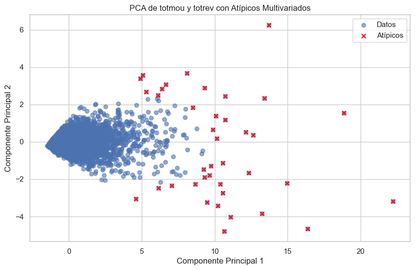

```python
scaler = StandardScaler()
data_scaled = scaler.fit_transform(ABT_1[['totmou', 'totrev']])

pca = PCA(n_components=2)
pca_data = pca.fit_transform(data_scaled)

cov_matrix = np.cov(pca_data, rowvar=False)
inv_cov_matrix = np.linalg.inv(cov_matrix)
mean_distr = pca_data.mean(axis=0)

def mahalanobis(x, mean, inv_cov):
    x_minus_mean = x - mean
    return np.sqrt(np.dot(np.dot(x_minus_mean, inv_cov), x_minus_mean.T))

distances = np.array([mahalanobis(x, mean_distr, inv_cov_matrix) for x in pca_data])

chi_square_threshold = chi2.ppf(0.975, df=2)
outliers = np.where(distances > chi_square_threshold)[0]

outlier_count = len(outliers)
remaining_count = len(ABT_1) - outlier_count

outliers_table = pd.DataFrame({
    'Categoría': ['Casos Eliminados', 'Casos Restantes'],
    'Conteo': [outlier_count, remaining_count]
})

print(outliers_table)

plt.figure(figsize=(10, 6))
plt.scatter(pca_data[:, 0], pca_data[:, 1], label='Datos', alpha=0.6)
plt.scatter(pca_data[outliers, 0], pca_data[outliers, 1], color='red', label='Atípicos', marker='x')
plt.xlabel('Componente Principal 1')
plt.ylabel('Componente Principal 2')
plt.title('PCA de totmou y totrev con Atípicos Multivariados')
plt.legend()
plt.show()

ABT_1_cleaned = ABT_1.drop(outliers).reset_index(drop=True)
```

### Relación entre Ingresos del cliente yTotal de minutos usados por el cliente.

#### Análisis gráfico, coeficiente de correlación no paramétrico y análisis de regresión

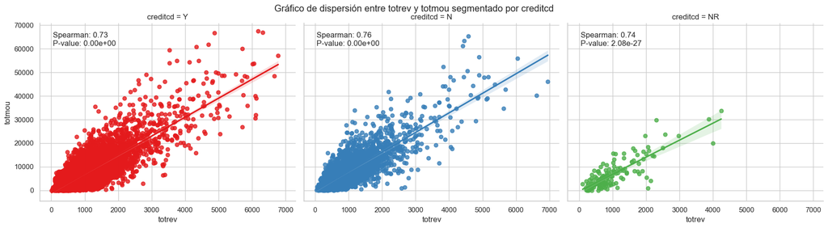

```python
# Función personalizada para agregar el coeficiente de Spearman y su p-valor por nivel de 'creditcd'
def annotate_by_group(data, **kws):
    creditcd_group = data['creditcd'].unique()[0]
    corr, p_value = stats.spearmanr(data['totrev'], data['totmou'])
    text = f"Spearman: {corr:.2f}\nP-value: {p_value:.2e}"
    ax = plt.gca()
    ax.text(0.05, 0.95, text, transform=ax.transAxes, fontsize=12, verticalalignment='top')

# Crear el gráfico de dispersión segmentado por la variable 'creditcd'
g = sns.lmplot(x='totrev', y='totmou', data=ABT_1_cleaned, hue='creditcd', col='creditcd', palette='Set1', aspect=1.2, height=5)

# Aplicar la función de anotación por cada panel basado en los niveles de 'creditcd'
g.map_dataframe(annotate_by_group)

plt.subplots_adjust(top=0.9)
g.fig.suptitle('Gráfico de dispersión entre totrev y totmou segmentado por creditcd')


plt.show()
```

Dado que el análisis exploratorio de datos reveló que ninguna de las variables (Totrev y Totmou)siguen una distribución normal, se procedió a estimar la relación en función del coeficiente de correlación por rangos de Sperman que se mostro estadísticamente significativo a un alpha de 0.05 y por encima de 0.73 (correlación positiva fuerte) independiente de si las personas tienen, no tienen o no reportan crédito.

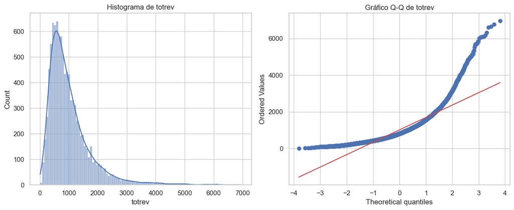

```
Shapiro-Wilk Test para totrev: W=0.7990, p-value=0.0000

Probando transformaciones en totrev:
```

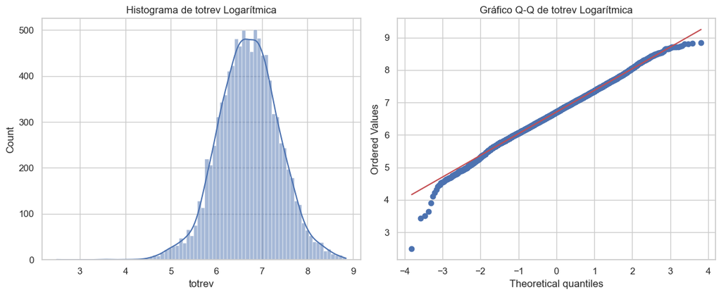

```
Shapiro-Wilk Test para totrev Logarítmica: W=0.9976, p-value=0.0000
```

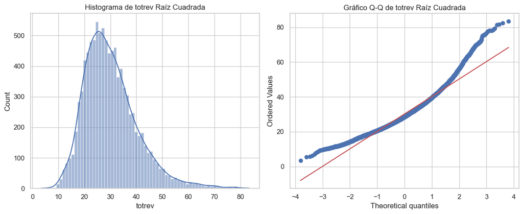

```
Shapiro-Wilk Test para totrev Raíz Cuadrada: W=0.9462, p-value=0.0000
Transformación Box-Cox para totrev: Lambda=0.0449
```

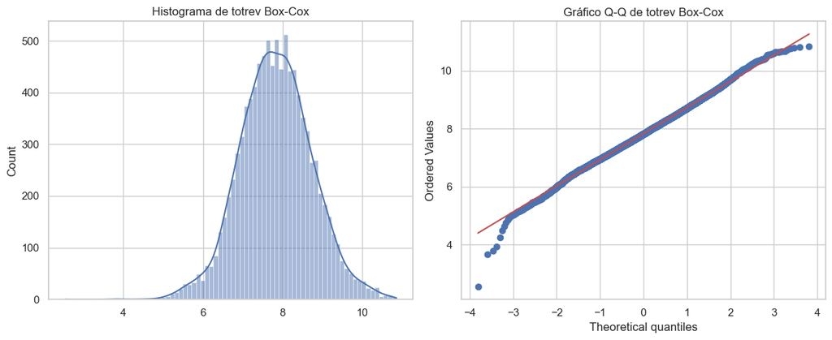

```
Shapiro-Wilk Test para totrev Box-Cox: W=0.9981, p-value=0.0000
No se logró normalidad para totrev con las transformaciones comunes.
```

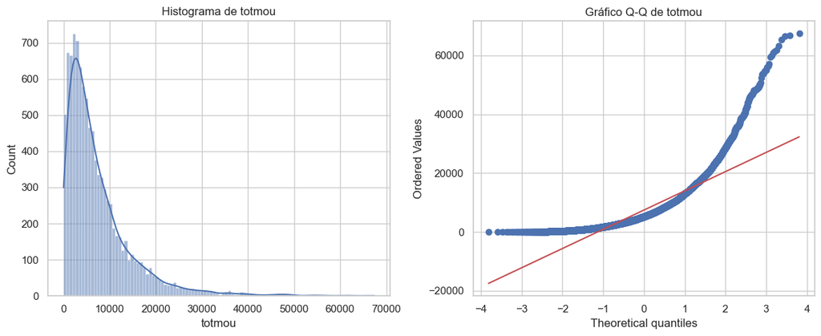

```
Shapiro-Wilk Test para totmou: W=0.7743, p-value=0.0000

Probando transformaciones en totmou:
```

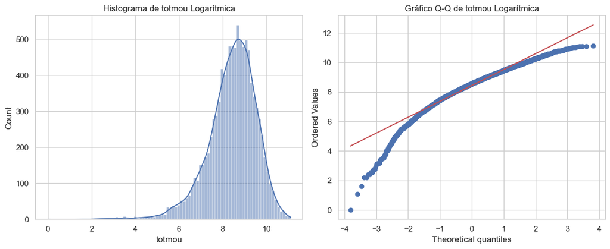

```
Shapiro-Wilk Test para totmou Logarítmica: W=0.9572, p-value=0.0000
```

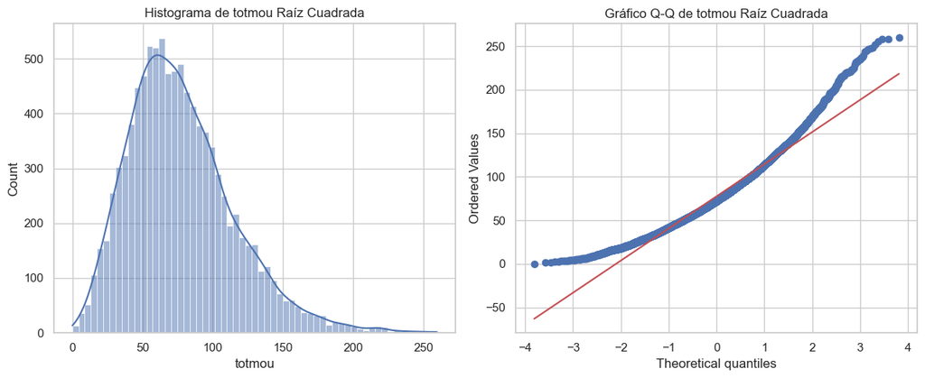

```
Shapiro-Wilk Test para totmou Raíz Cuadrada: W=0.9597, p-value=0.0000
No se logró normalidad para totmou con las transformaciones comunes.
```

```python
# Función para verificar la normalidad de una variable mediante el test de Shapiro-Wilk
def check_normality(variable, var_name):
    stat, p_value = stats.shapiro(variable)
    print(f"Shapiro-Wilk Test para {var_name}: W={stat:.4f}, p-value={p_value:.4f}")
    return p_value > 0.05  # Retorna True si la variable es normal

# Función para graficar histogramas y gráficos Q-Q para una variable
def plot_distribution(variable, var_name):
    plt.figure(figsize=(12, 5))


    plt.subplot(1, 2, 1)
    sns.histplot(variable, kde=True)
    plt.title(f"Histograma de {var_name}")


    plt.subplot(1, 2, 2)
    stats.probplot(variable, dist="norm", plot=plt)
    plt.title(f"Gráfico Q-Q de {var_name}")

    plt.tight_layout()
    plt.show()

# Transformación Box-Cox
def boxcox_transformation(variable, var_name):
    positive_values = variable[variable > 0]
    transformed, lambda_value = stats.boxcox(positive_values)
    print(f"Transformación Box-Cox para {var_name}: Lambda={lambda_value:.4f}")
    return transformed

# Aplicar transformaciones hasta lograr normalidad
def transform_to_normality(dataframe, variable_name):
    variable = dataframe[variable_name]

    # Verificar la normalidad original
    plot_distribution(variable, variable_name)
    is_normal = check_normality(variable, variable_name)


    if not is_normal:
        print(f"\nProbando transformaciones en {variable_name}:\n")

        # Intentar transformación logarítmica
        transformed_log = np.log1p(variable)  # log(1 + x) para manejar ceros
        plot_distribution(transformed_log, f"{variable_name} Logarítmica")
        if check_normality(transformed_log, f"{variable_name} Logarítmica"):
            print(f"{variable_name} es normal después de la transformación logarítmica.")
            return transformed_log

        # Intentar transformación de raíz cuadrada
        transformed_sqrt = np.sqrt(variable)
        plot_distribution(transformed_sqrt, f"{variable_name} Raíz Cuadrada")
        if check_normality(transformed_sqrt, f"{variable_name} Raíz Cuadrada"):
            print(f"{variable_name} es normal después de la transformación de raíz cuadrada.")
            return transformed_sqrt

        # Intentar transformación Box-Cox
        if (variable > 0).all():  # Box-Cox requiere valores positivos
            transformed_boxcox = boxcox_transformation(variable, variable_name)
            plot_distribution(transformed_boxcox, f"{variable_name} Box-Cox")
            if check_normality(transformed_boxcox, f"{variable_name} Box-Cox"):
                print(f"{variable_name} es normal después de la transformación Box-Cox.")
                return transformed_boxcox

        print(f"No se logró normalidad para {variable_name} con las transformaciones comunes.")
    else:
        print(f"{variable_name} ya es normal.")
        return variable

# Aplicar transformaciones a las variables 'totrev' y 'totmou'
ABT_1_cleaned['totrev_normalized'] = transform_to_normality(ABT_1_cleaned, 'totrev')
ABT_1_cleaned['totmou_normalized'] = transform_to_normality(ABT_1_cleaned, 'totmou')
```

Luego de probar las transformaciones comunes (logaritmo, raiz cuadrada y boxcox) las variables no se comportaron conforme la distribución noral, supuesto básico para crear regresión lineal.

Se procede a hacer una regresión cuantílica, estimando la mediana o percentil 50, la cual es robusta en ausencia de valores atípicos u no tiene supuestos de normalidad en variables de ingreso

```python
# Ajustar un modelo de regresión cuantílica para la mediana (percentil 0.5)
quant_reg_model = smf.quantreg('totmou ~ totrev', ABT_1_cleaned)
quant_reg_fit = quant_reg_model.fit(q=0.5)  # q=0.5 para la mediana

# Mostrar el resumen del modelo
print(quant_reg_fit.summary())
```

```
                         QuantReg Regression Results
==============================================================================
Dep. Variable:                 totmou   Pseudo R-squared:               0.3993
Model:                       QuantReg   Bandwidth:                       677.8
Method:                 Least Squares   Sparsity:                        6904.
Date:                Sat, 19 Oct 2024   No. Observations:                 9961
Time:                        18:18:56   Df Residuals:                     9959
                                        Df Model:                            1
==============================================================================
                 coef    std err          t      P>|t|      [0.025      0.975]
------------------------------------------------------------------------------
Intercept   -792.7127     58.038    -13.659      0.000    -906.478    -678.947
totrev         7.5819      0.046    165.693      0.000       7.492       7.672
==============================================================================

The condition number is large, 2.13e+03. This might indicate that there are
strong multicollinearity or other numerical problems.
```

Existe una relación positiva y significativa entre el ingreso del cliente y el tiempo que utiliza. Por cada unidad adicional de ingreso, se espera que el tiempo que el cliente usa aumente en 7.58 unidades.

El pseudo R-cuadrado indica que el ingreso explica una parte considerable de la variación en el tiempo usado por el cliente, pero hay otros factores que podrían ser relevantes.

Aunque el modelo es estadísticamente significativo, se debe revisar el número de condición para investigar posibles problemas con los datos que podrían afectar la interpretación o estabilidad del modelo.

Se propone un segundo modelo, agregando la antiguedad del cliente como variable explicativa.

```python
quant_reg_model = smf.quantreg('totmou ~ totrev + eqpdays', ABT_1_cleaned)
quant_reg_fit = quant_reg_model.fit(q=0.5)  # q=0.5 para la mediana

print(quant_reg_fit.summary())
```

```
                         QuantReg Regression Results
==============================================================================
Dep. Variable:                 totmou   Pseudo R-squared:               0.4386
Model:                       QuantReg   Bandwidth:                       626.6
Method:                 Least Squares   Sparsity:                        6301.
Date:                Sat, 19 Oct 2024   No. Observations:                 9961
Time:                        18:23:29   Df Residuals:                     9958
                                        Df Model:                            2
==============================================================================
                 coef    std err          t      P>|t|      [0.025      0.975]
------------------------------------------------------------------------------
Intercept    692.2736     69.711      9.931      0.000     555.626     828.921
totrev         7.9464      0.042    189.788      0.000       7.864       8.029
eqpdays       -4.9142      0.125    -39.250      0.000      -5.160      -4.669
==============================================================================

The condition number is large, 2.9e+03. This might indicate that there are
strong multicollinearity or other numerical problems.
```

Comparación con el modelo anterior:

Incorporación de eqpdays: En el nuevo modelo, eqpdays se ha agregado como variable explicativa. Su coeficiente negativo indica que esta variable tiene un efecto inverso en el tiempo usado por el cliente. Esto añade valor al modelo al explicar más variación en la variable dependiente.

Cambio en el coeficiente de totrev: El coeficiente del ingreso (totrev) ha aumentado ligeramente en el nuevo modelo (de 7.58 a 7.95), lo que sugiere que el ingreso sigue siendo un predictor muy fuerte del tiempo usado, incluso después de ajustar por los días de uso del equipo.

Mejor ajuste: El pseudo R-cuadrado ha mejorado, lo que indica que el modelo con ambas variables explicativas explica mejor la variabilidad en el tiempo utilizado por el cliente en comparación con el modelo que solo tenía totrev.

Multicolinealidad potencial: Aunque el número de condición sigue siendo alto, esto sugiere la necesidad de investigar más a fondo la relación entre totrev y eqpdays.

Conclusión:

El nuevo modelo es más robusto al incluir tanto el ingreso como los días de uso del equipo, y logra explicar una mayor parte de la variación en el tiempo usado por el cliente. Sin embargo, es recomendable investigar si hay colinealidad entre las variables explicativas y considerar posibles efectos sobre la interpretación y estabilidad del modelo.

```python
spearman_corr, p_value = stats.spearmanr(ABT_1_cleaned['totrev'], ABT_1_cleaned['eqpdays'])

print(f"Coeficiente de Spearman: {spearman_corr:.4f}")
print(f"P-valor: {p_value:.4e}")
```

```
Coeficiente de Spearman: 0.1226
P-valor: 1.1711e-34
```

A mayor antiguedad del cliente, el consumo de minutos baja, a mayor ingreso, el consumo sube en proporción al coeficiente.